# Preprocessing - taxonomy data

[figure not shown]

[figure not shown]

[figure not shown]

[figure not shown]

Sample summary

Filtering

Unsupervised clustering

Session info

#### Basic statistics

Number of runs: 1  
Number of samples (input count >0 for kraken data): 344  
Number of controls: 0

#### Sample type by country (includes replicates)

```
      India Malawi
  BS3   283     61
```

#### Minimum, median, and maximum output counts by country

```
  country        n      min      med      max
1   India      283  1900705 13901700 36117791
2  Malawi       61   900399  9259874 28618052
```

#### Step 1: load unfiltered feature table - ps1

- n samples: 344
- n features: 6949
- total reads (million): 4802.075114

- n samples: 344
- n features: 5718
- total reads (million): 4771.330703

- n samples: 344
- n features: 251
- total reads (million): 4753.444088

#### Select rarefaction depth

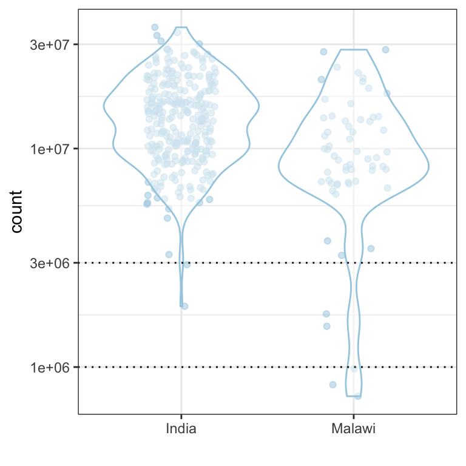

Line displays depth of 1M and 3M sequences.

```
         n d1M d3M d5M
India  283 283 281 279
Malawi  61  58  56  53
```

Rarefaction depth of 10^{6} sequences per sample retains 100% of Indian samples and 95.1% of Malawian samples.

#### Step 4: remove samples with <1M sequences - ps4

- n samples: 341
- n features: 251
- total reads (million): 4750.895379
- excluded samples: M001BS3, M077BS3, M104BS3

#### Step 5: rarefy to 1M sequences - ps5

- n samples: 341
- n features: 251
- total reads (million): 341

#### Filtering statistics

```
                       n_samples n_taxa total_count     min     mean      sd
ps1 (unfiltered)             344   6949  4802075114  900399 13959521 6400949
ps2 (taxonomy)               344   5718  4771330703  739619 13870147 6396024
ps3 (≥0.1% in >1)            344    251  4753444088  735369 13818151 6391412
ps4 (samples with ≥1M)       341    251  4750895379 1536686 13932245 6301862
ps5 (rarefied to 1M)         341    251   341000000 1000000  1000000       0
```

#### Boxplots of filtering statistics by country

[figure not shown]

#### Clustering of samples (columns) and taxa (rows) - presence/absence at genus level

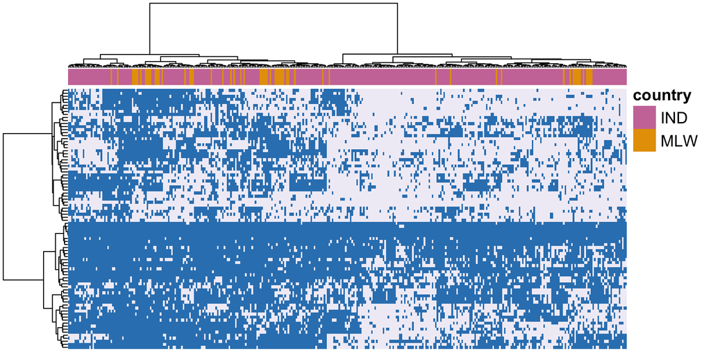

Number of features: 86  
Number of samples include: 341

#### Clustering of samples (columns) and taxa (rows) - presence/absence at species level

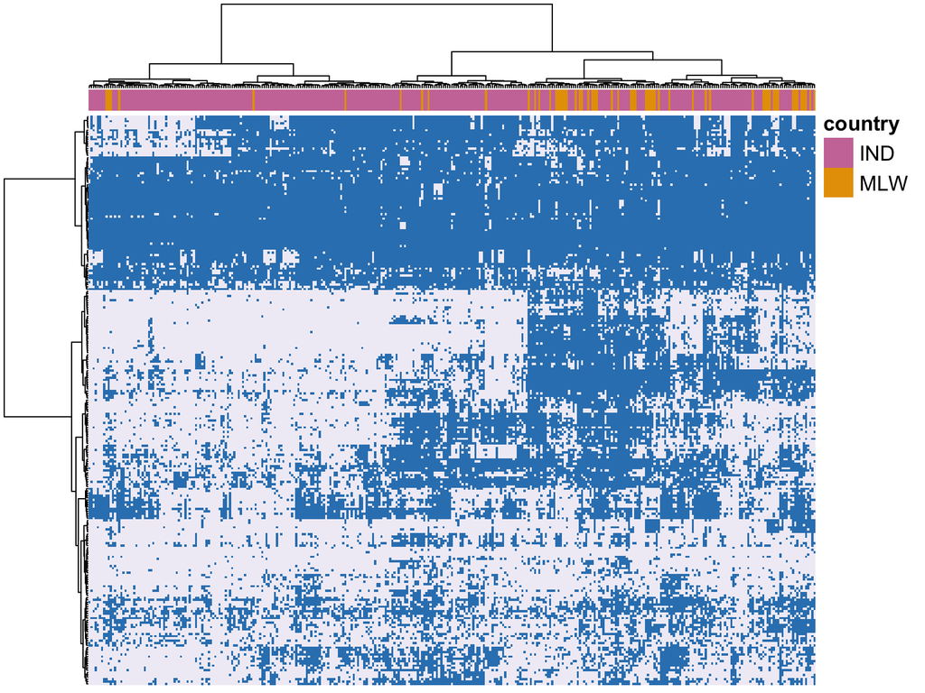

Number of features: 251  
Number of samples include: 341

```
R version 4.2.1 (2022-06-23)
Platform: x86_64-apple-darwin17.0 (64-bit)
Running under: macOS Big Sur ... 10.16

Matrix products: default
BLAS:   /Library/Frameworks/R.framework/Versions/4.2/Resources/lib/libRblas.0.dylib
LAPACK: /Library/Frameworks/R.framework/Versions/4.2/Resources/lib/libRlapack.dylib

locale:
[1] en_GB.UTF-8/en_GB.UTF-8/en_GB.UTF-8/C/en_GB.UTF-8/en_GB.UTF-8

attached base packages:
[1] parallel  stats4    stats     graphics  grDevices utils     datasets
[8] methods   base

other attached packages:
 [1] biomformat_1.24.0      Maaslin2_1.10.0        FSA_0.9.3
 [4] ALDEx2_1.28.1          zCompositions_1.4.0-1  truncnorm_1.0-8
 [7] NADA_1.6-1.1           survival_3.4-0         MASS_7.3-58.1
[10] sjstats_0.18.1         ggExtra_0.10.0         formattable_0.2.1
[13] inlmisc_0.5.5          wesanderson_0.3.6      phangorn_2.10.0
[16] ape_5.6-2              DECIPHER_2.24.0        RSQLite_2.2.18
[19] Biostrings_2.64.1      GenomeInfoDb_1.32.4    XVector_0.36.0
[22] IRanges_2.30.1         S4Vectors_0.34.0       BiocGenerics_0.42.0
[25] cowplot_1.1.1          scales_1.2.1           RVAideMemoire_0.9-81-2
[28] DescTools_0.99.47      ggsignif_0.6.4         binom_1.1-1.1
[31] shiny_1.7.3            randomcoloR_1.1.0.1    crossval_1.0.4
[34] labdsv_2.0-1           mgcv_1.8-41            nlme_3.1-160
[37] ggpubr_0.4.0           data.table_1.14.4      corrplot_0.92
[40] vegan_2.6-4            lattice_0.20-45        permute_0.9-7
[43] randomForest_4.7-1.1   matrixStats_0.62.0     lme4_1.1-30
[46] Matrix_1.5-1           reshape2_1.4.4         pheatmap_1.0.12
[49] DT_0.26                plotly_4.10.0          cluster_2.1.4
[52] tidyr_1.2.1            dplyr_1.0.10           magrittr_2.0.3
[55] plyr_1.8.7             kableExtra_1.3.4       gridExtra_2.3
[58] RColorBrewer_1.1-3     knitr_1.40             ggplot2_3.3.6
[61] phyloseq_1.40.0

loaded via a namespace (and not attached):
  [1] estimability_1.4.1          coda_0.19-4
  [3] bit64_4.0.5                 DelayedArray_0.22.0
  [5] RCurl_1.98-1.9              generics_0.1.3
  [7] terra_1.6-17                proxy_0.4-27
  [9] bit_4.0.4                   webshot_0.5.4
 [11] xml2_1.3.3                  httpuv_1.6.6
 [13] SummarizedExperiment_1.26.1 assertthat_0.2.1
 [15] xfun_0.34                   jquerylib_0.1.4
 [17] evaluate_0.17               promises_1.2.0.1
 [19] DEoptimR_1.0-11             fansi_1.0.3
 [21] readxl_1.4.1                igraph_1.3.5
 [23] DBI_1.1.3                   htmlwidgets_1.5.4
 [25] purrr_0.3.5                 ellipsis_0.3.2
 [27] backports_1.4.1             V8_4.2.1
 [29] insight_0.18.6              MatrixGenerics_1.8.1
 [31] vctrs_0.5.0                 Biobase_2.56.0
 [33] sjlabelled_1.2.0            abind_1.4-5
 [35] cachem_1.0.6                withr_2.5.0
 [37] robustbase_0.95-0           rgdal_1.5-32
 [39] emmeans_1.8.2               getopt_1.20.3
 [41] svglite_2.1.0               lazyeval_0.2.2
 [43] crayon_1.5.2                flexdashboard_0.6.0
 [45] labeling_0.4.2              pkgconfig_2.0.3
 [47] rlang_1.0.6                 lifecycle_1.0.3
 [49] miniUI_0.1.1.1              modelr_0.1.9
 [51] cellranger_1.1.0            datawizard_0.6.3
 [53] raster_3.6-3                carData_3.0-5
 [55] lpsymphony_1.24.0           Rhdf5lib_1.18.2
 [57] boot_1.3-28                 viridisLite_0.4.1
 [59] parameters_0.19.0           rootSolve_1.8.2.3
 [61] bitops_1.0-7                rhdf5filters_1.8.0
 [63] blob_1.2.3                  stringr_1.4.1
 [65] rstatix_0.7.0               memoise_2.0.1
 [67] zlibbioc_1.42.0             compiler_4.2.1
 [69] cli_3.4.1                   ade4_1.7-19
 [71] tidyselect_1.2.0            stringi_1.7.8
 [73] highr_0.9                   yaml_2.3.6
 [75] grid_4.2.1                  sass_0.4.2
 [77] fastmatch_1.1-3             tools_4.2.1
 [79] lmom_2.9                    rstudioapi_0.14
 [81] foreach_1.5.2               optparse_1.7.3
 [83] gld_2.6.6                   farver_2.1.1
 [85] Rtsne_0.16                  RcppZiggurat_0.1.6
 [87] digest_0.6.30               quadprog_1.5-8
 [89] Rcpp_1.0.9                  GenomicRanges_1.48.0
 [91] car_3.1-1                   broom_1.0.1
 [93] performance_0.10.0          later_1.3.0
 [95] httr_1.4.4                  effectsize_0.8.1
 [97] colorspace_2.0-3            rvest_1.0.3
 [99] splines_4.2.1               expm_0.999-6
[101] sp_1.5-0                    multtest_2.52.0
[103] Exact_3.2                   systemfonts_1.0.4
[105] xtable_1.8-4                jsonlite_1.8.3
[107] nloptr_2.0.3                Rfast_2.0.6
[109] R6_2.5.1                    pillar_1.8.1
[111] htmltools_0.5.3             mime_0.12
[113] glue_1.6.2                  fastmap_1.1.0
[115] minqa_1.2.5                 BiocParallel_1.30.4
[117] class_7.3-20                codetools_0.2-18
[119] pcaPP_2.0-3                 mvtnorm_1.1-3
[121] utf8_1.2.2                  bslib_0.4.0
[123] tibble_3.1.8                curl_4.3.3
[125] biglm_0.9-2.1               rmarkdown_2.17
[127] munsell_0.5.0               e1071_1.7-12
[129] rhdf5_2.40.0                GenomeInfoDbData_1.2.8
[131] iterators_1.0.14            sjmisc_2.8.9
[133] gtable_0.3.1                bayestestR_0.13.0
```

.